# Canonical Correlation and MANOVA

## Resources

- Borcard et al. (2011) *Numerical Ecology with R*. Springer.
- Everitt and Hothorn (2011) *An Introduction to Applied Multivariate Analysis with R*. Springer.
- Tabachnick and Fidell (2013): *Using Multivariate Statistics*. Pearson.

## Approaches to continuous data

*Correlation*:

- 2 interchangeable variables

*PCA*:

- 0 outcome variables (`~ .`)
- *q* possibly correlated variables

*Multiple regression*:

- 1 continuous outcome variable
- *q* predictors

## Canonical correlation

Correlations of *linear combinations* of a set of multiple continuous variables with a separate set of multiple continuous variables.

- Multiple variables ~ Multiple variables
- Weather variables vs. Growth variables
- Ecology variables vs. Urbanization variables
- Diversity variables vs. Landscape variables

## Canonical correlation

*Pairs* of canonical variates:

- Like a PCA on both sets of variables, but constrained to maximize the correlation between the *i*th pair of composite variables (canonical correlates)
- However, *not just the correlation of PCs*.

## Wheat

> “Two identical 13.6-ton (500 bu.) parcels of Manitoba Northern wheat, variety Selkirk, were stored 183 cm deep in 2 similar and adjoining 305 cm X 333 cm wooden bins in a granary in Winnipeg during 1959-67. Two hundred-gram samples were collected monthly from fixed sampling sites in the bins.” Sinha et al. (1969)

Measure biotic (insects, fungi, mites) and abiotic (location, depth, temperature) factors.

- How do these correlate?

## Wheat

[figure not shown]

## Generating multivariate data

Generate multivariate normal data with a specified correlation coefficient:

```r
MVnorm <- function(n, rho, mu, lab, sigma = 1) {
  Sigma <- matrix(c(sigma ^ 2, rho * sigma ^ 2,
                    rho * sigma ^ 2, sigma ^ 2), 2)
  x <- MASS::mvrnorm(n, mu, Sigma, empirical = TRUE)
  colnames(x) <- paste0(lab, 1:2)
  return(x)
}
```

```r
set.seed(10)
X <- MVnorm(n = 30, rho = 0.5, mu = c(0, 0), lab = "X")
Y <- MVnorm(n = 30, rho = 0.7, mu = c(0, 0), lab = "Y")
```

## Generating multivariate data

```r
head(X)
```

```
##               X1         X2
## [1,]  1.84077435  0.8214853
## [2,] -0.04296592  0.1569903
## [3,] -1.11464419 -1.3386851
## [4,] -0.30795460 -0.3394466
## [5,]  1.32629159  0.9854753
## [6,]  1.38203836  1.0982167
```

```r
head(Y)
```

```
##               Y1         Y2
## [1,] -0.50978568 -1.2961719
## [2,] -0.08494414 -0.4868463
## [3,] -0.54060148 -0.8297993
## [4,] -0.41666750  0.4729511
## [5,]  0.50455898  1.1321715
## [6,]  1.99373316  1.0386046
```

## Canonical correlation in R

`cancor()`

- Built-in R function
- Rudimentary but functional

`candisc`

- Overrides `cancor()` with its own version
- Useful plotting functions

`CCA::cc()`

- `CCA` package extension of `cancor()`
- Plotting functions
- Handles missing data

## Canonical correlation

```r
library(candisc)
z <- cancor(X, Y)
z
```

```
##
## Canonical correlation analysis of:
##   2   X  variables:  X1, X2
##   with    2   Y  variables:  Y1, Y2
##
##      CanR   CanRSQ    Eigen percent    cum                          scree
## 1 0.34660 0.120133 0.136536  98.671  98.67 ******************************
## 2 0.04285 0.001836 0.001839   1.329 100.00
##
## Test of H0: The canonical correlations in the
## current row and all that follow are zero
##
##      CanR LR test stat approx F numDF denDF Pr(> F)
## 1 0.34660      0.87825  0.87184     4    52  0.4872
## 2 0.04285      0.99816  0.04966     1    27  0.8253
```

## Canonical correlates

```r
z$cancor
```

```
## [1] 0.34660264 0.04284832
```

Canonical correlates:

1. Xcan1 vs. Ycan1: 0.35
2. Xcan2 vs. Ycan2: 0.04

## Canonical coefficients

```r
z$coef
```

```
## $X
##         Xcan1      Xcan2
## X1 -0.7887883 -0.8432949
## X2 -0.3359207  1.1047582
##
## $Y
##         Ycan1     Ycan2
## Y1 0.07751181  1.398133
## Y2 0.94420850 -1.034048
```

Interpret as you would multiple regression:

- 1 unit increase in `X1` leads to a -0.79 unit increase in CCx1 when all other variables are constant

## Canonical loadings

```r
z$structure
```

```
## $X.xscores
##         Xcan1      Xcan2
## X1 -0.9567486 -0.2909159
## X2 -0.7303148  0.6831107
##
## $Y.xscores
##        Xcan1        Xcan2
## Y1 0.2559514  0.028892608
## Y2 0.3460712 -0.002371847
##
## $X.yscores
##         Ycan1       Ycan2
## X1 -0.3316116 -0.01246525
## X2 -0.2531291  0.02927014
##
## $Y.yscores
##        Ycan1      Ycan2
## Y1 0.7384578  0.6742997
## Y2 0.9984668 -0.0553545
```

## CCA is adirectional

Are the coefficients equal up to some small tolerance value?

```r
all.equal(cancor(X, Y)$cancor, cancor(Y, X)$cancor)
```

```
## [1] TRUE
```

- the multivariate equivalent of `cor(x, y) == cor(y, x)`.

## Visualizing

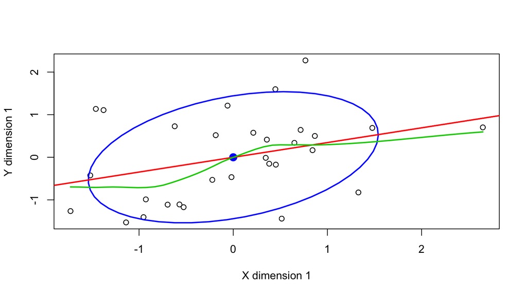

```r
plot(z, which = 1, smooth = TRUE)
```

## Visualizing

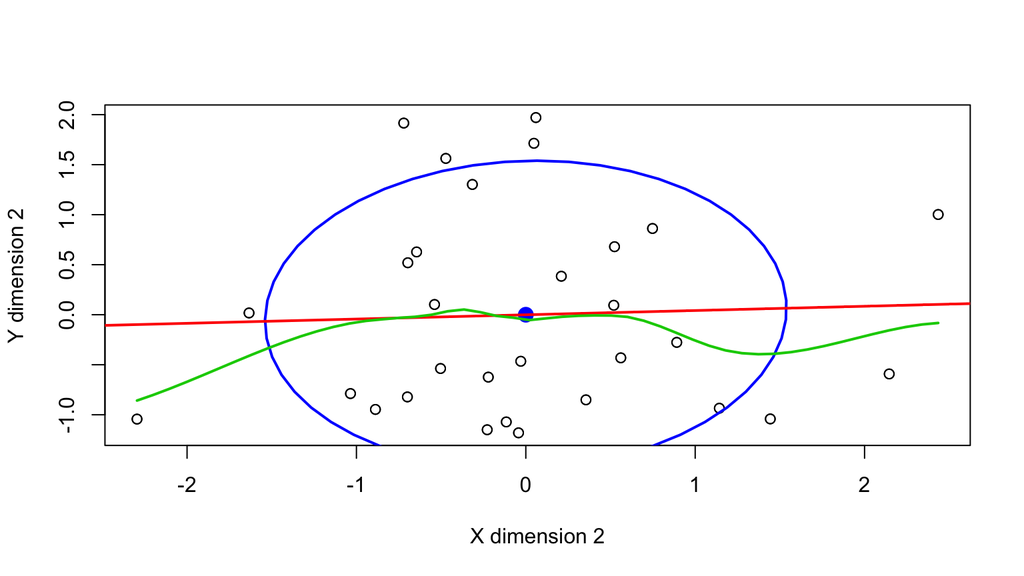

```r
plot(z, which = 2, smooth = TRUE)
```

## Head measurements

Head length and breadth from 25 pairs of sons:

```r
M <- read_excel("../data/headsize.xlsx")
str(M)
```

```
## Classes 'tbl_df', 'tbl' and 'data.frame':    25 obs. of  4 variables:
##  $ head1   : num  191 195 181 183 176 208 189 197 188 192 ...
##  $ breadth1: num  155 149 148 153 144 157 150 159 152 150 ...
##  $ head2   : num  179 201 185 188 171 192 190 189 197 187 ...
##  $ breadth2: num  145 152 149 149 142 152 149 152 159 151 ...
```

## Head measurements

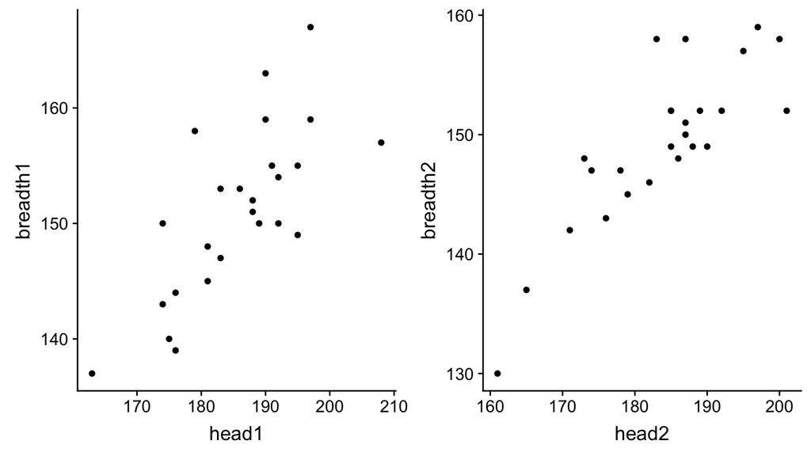

## Head measurements

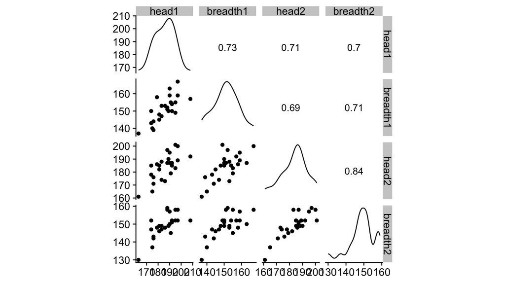

```r
ggscatmat(M)
```

## Head measurements

Split into two matrices and convert to *Z*-scores:

```r
M1 <- M %>% select(head1, breadth1) %>% as.matrix() %>% scale()
M2 <- M %>% select(head2, breadth2) %>% as.matrix() %>% scale()
```

Canonical correlation

```r
z <- cancor(M1, M2, set.names = c("First Born", "Second Born"))
z$cancor
```

```
## [1] 0.7885079 0.0537397
```

## Head measurements

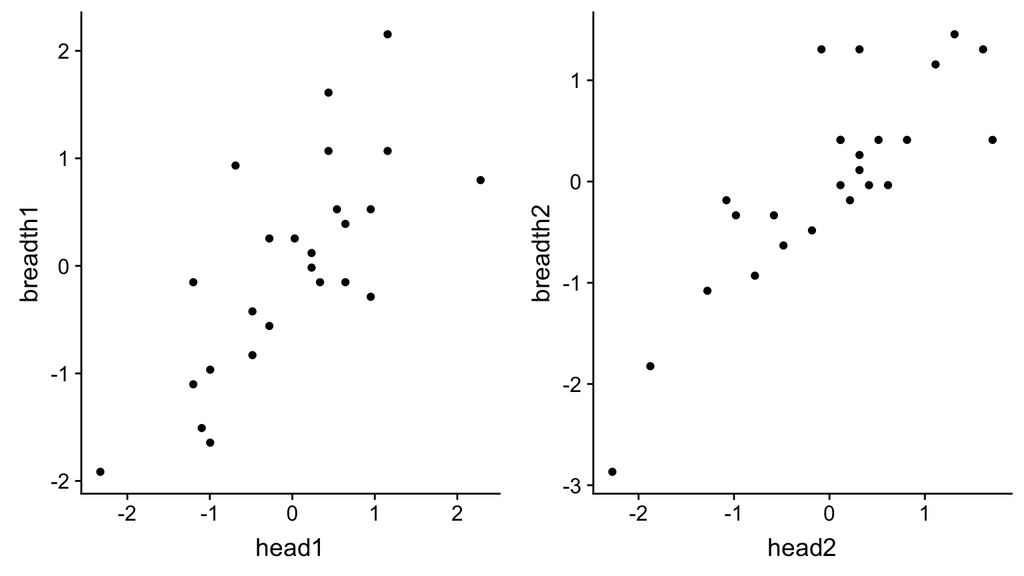

## Head measurements

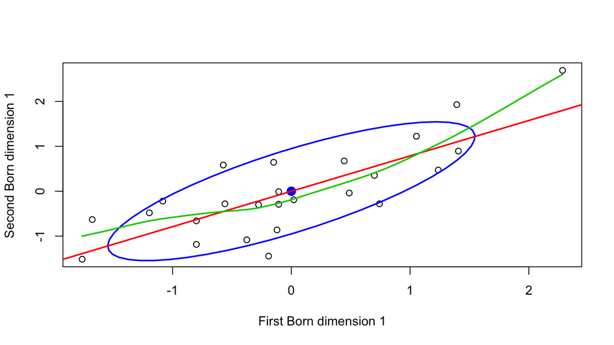

```r
plot(z, which = 1, smooth = TRUE)
```

## Head measurements

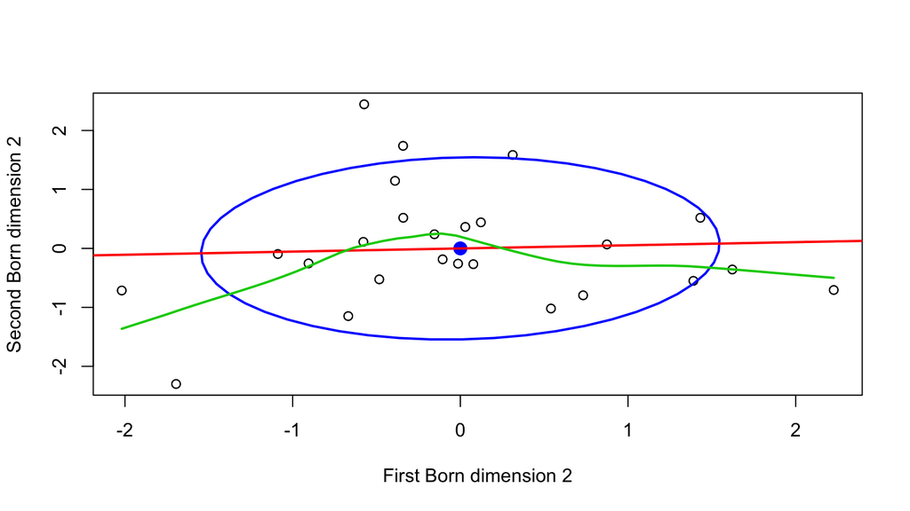

```r
plot(z, which = 2, smooth = TRUE)
```

## Head measurements

Canonical coefficients

```r
z$coef
```

```
## $X
##               Xcan1     Xcan2
## head1    -0.5521896 -1.366374
## breadth1 -0.5215372  1.378365
##
## $Y
##               Ycan1     Ycan2
## head2    -0.5044484 -1.768570
## breadth2 -0.5382877  1.758566
```

## Head measurements

Standardized canonical loadings

```r
z$structure
```

```
## $X.xscores
##               Xcan1      Xcan2
## head1    -0.9352877 -0.3538884
## breadth1 -0.9271512  0.3746875
##
## $Y.xscores
##               Xcan1       Xcan2
## head2    -0.7539771 -0.01572908
## breadth2 -0.7582663  0.01474027
##
## $X.yscores
##               Ycan1       Ycan2
## head1    -0.7374817 -0.01901786
## breadth1 -0.7310660  0.02013559
##
## $Y.yscores
##               Ycan1      Ycan2
## head2    -0.9562074 -0.2926900
## breadth2 -0.9616470  0.2742901
```

## Multivariate (Gaussian) linear models

Directional:

- `outcome variables ~ predictor variables`
1. “MLM”: *p* Continuous ~ *q* Continuous
2. MANOVA and Hotelling’s *T*<sup>2</sup>: *p* Continuous ~ *q* Categorical
3. MANCOVA: *p* Continuous ~ *q* Categorical + *r* Continuous
4. (Multiple) correspondence analysis: *p* Categorical ~ *q* Categorical

MANOVA creates a composite variable from the set of outcome variables and asks whether the groups differ.

## General approach

1. Think about the question you want to answer
2. Group the outcome variables into a single matrix (`cbind()`)
3. Fit a linear model with `lm()`, predicting the outcome matrix by some predictors using formula notation
4. Analyze with `Anova()` and visualize with `plot()` and `heplot()` (Friendly 2006)

## Head measurements

```r
(fm <- lm(cbind(head1, breadth1) ~ head2 + breadth2, data = M))
```

```
##
## Call:
## lm(formula = cbind(head1, breadth1) ~ head2 + breadth2, data = M)
##
## Coefficients:
##              head1    breadth1
## (Intercept)  34.2823  35.8024
## head2         0.3944   0.2447
## breadth2      0.5289   0.4713
```

## Head measurements

```r
coef(lm(head1 ~ head2 + breadth2, data = M))
```

```
## (Intercept)       head2    breadth2
##  34.2823165   0.3944068   0.5288792
```

```r
coef(lm(breadth1 ~ head2 + breadth2, data = M))
```

```
## (Intercept)       head2    breadth2
##  35.8023808   0.2446617   0.4713147
```

## Head measurements

```r
Anova(fm, type = "III")
```

```
##
## Type III MANOVA Tests: Pillai test statistic
##             Df test stat approx F num Df den Df Pr(>F)
## (Intercept)  1   0.10219   1.1952      2     21 0.3224
## head2        1   0.11217   1.3266      2     21 0.2867
## breadth2     1   0.12546   1.5063      2     21 0.2447
```

Pillai–Bartlett statistic is the most robust of the various statistics (Wilk’s \(\Lambda\), Hotelling’s trace) that are most often reported.

## Head measurements

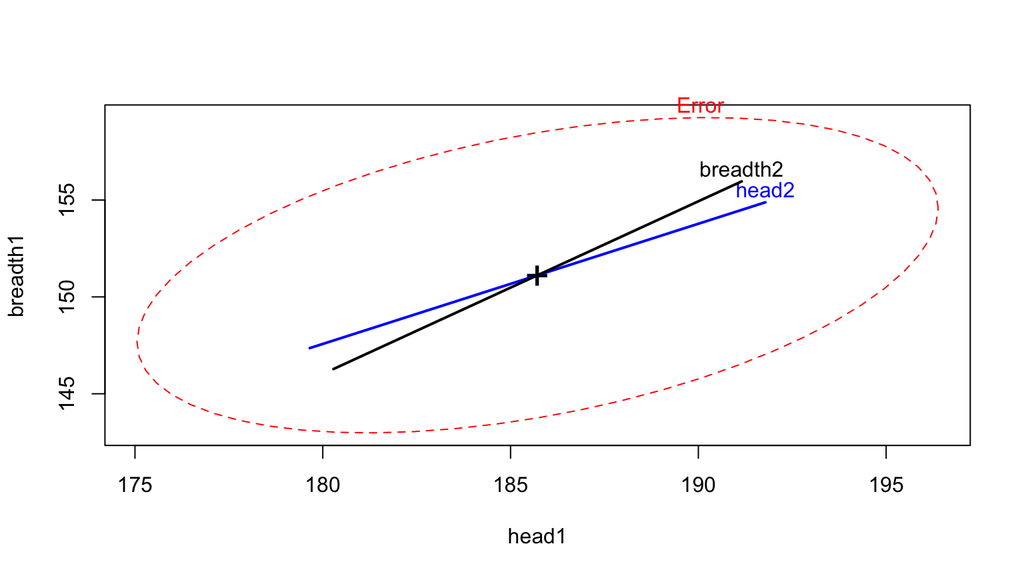

```r
heplot(fm)
```

## Drug testing

```r
M <- read_excel("../data/Drug_test.xlsx")
M$Treatment <- factor(M$Treatment)
str(M)
```

```
## Classes 'tbl_df', 'tbl' and 'data.frame':    38 obs. of  4 variables:
##  $ Fever    : num  38.4 36.8 37.1 39.8 38.6 39.1 38.9 36.8 38.2 39.4 ...
##  $ BP       : num  73 85 58 80 68 52 79 100 64 53 ...
##  $ Pain     : num  18 14 20 20 25 27 26 8 21 22 ...
##  $ Treatment: Factor w/ 2 levels "Drug","Placebo": 1 1 1 1 1 1 1 1 1 1 ...
```

## Drug testing

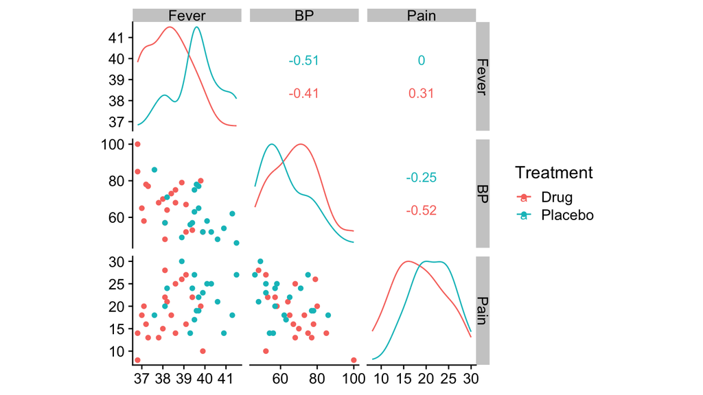

```r
ggscatmat(M, 1:3, color = "Treatment")
```

## Drug testing

```r
fm <- lm(cbind(Fever, BP, Pain) ~ Treatment, data = M)
fm
```

```
##
## Call:
## lm(formula = cbind(Fever, BP, Pain) ~ Treatment, data = M)
##
## Coefficients:
##                   Fever   BP      Pain
## (Intercept)       38.210  68.450  18.300
## TreatmentPlacebo   1.462  -7.006   3.200
```

## Drug testing

```r
Anova(fm, type = "III")
```

```
##
## Type III MANOVA Tests: Pillai test statistic
##             Df test stat approx F num Df den Df    Pr(>F)
## (Intercept)  1   0.99916  13502.5      3     34 < 2.2e-16 ***
## Treatment    1   0.37815      6.9      3     34 0.0009489 ***
## ---
## Signif. codes:  0 '***' 0.001 '**' 0.01 '*' 0.05 '.' 0.1 ' ' 1
```

## Drug testing

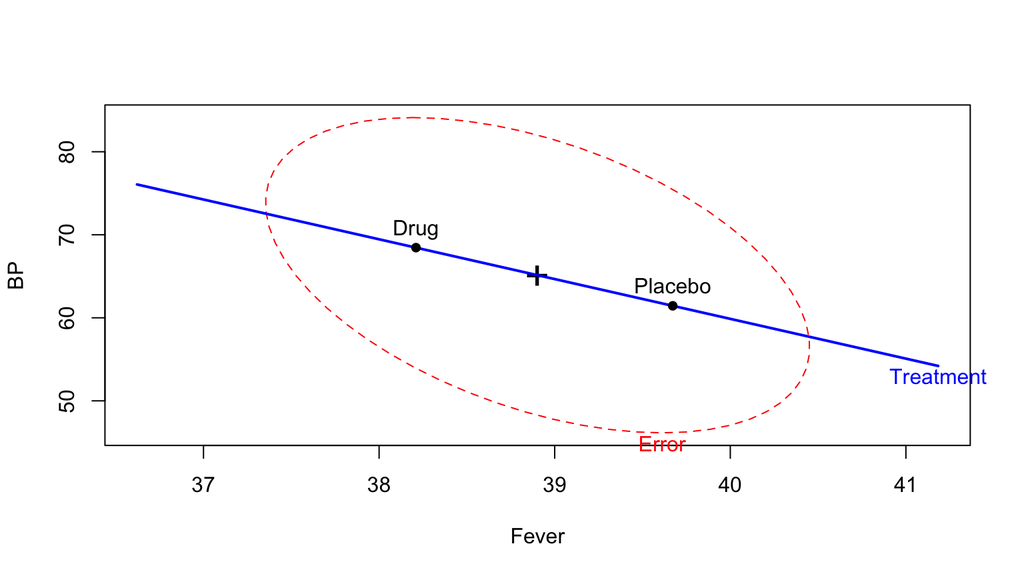

```r
heplot(fm, type = "III")
```

## Drug testing

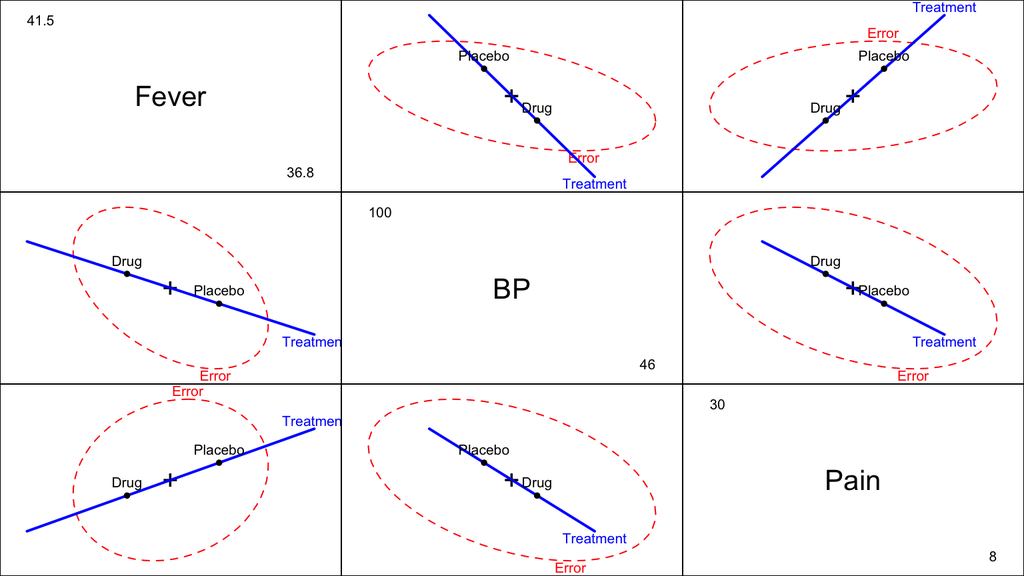

```r
pairs(fm, type = "III")
```

## Tibetan skulls

Morant (1923) published data on 32 skulls from Tibet:

```r
M <- read_excel("../data/Tibetan_Skulls.xlsx")
str(M)
```

```
## Classes 'tbl_df', 'tbl' and 'data.frame':    32 obs. of  6 variables:
##  $ Skull_Length: num  190 172 167 170 175 ...
##  $ Skull_Width : num  152 132 130 150 138 ...
##  $ Skull_Height: num  145 126 126 134 126 ...
##  $ Face_Height : num  73.5 63 69.5 64.5 77.5 71.5 70.5 73.5 70 62 ...
##  $ Face_Breadth: num  136 121 120 128 136 ...
##  $ Origin      : chr  "Sikkim" "Sikkim" "Sikkim" "Sikkim" ...
```

```r
M <- M %>% mutate(Origin = factor(Origin))
```

## Tibetan skulls

[figure not shown]

## Tibetan skulls

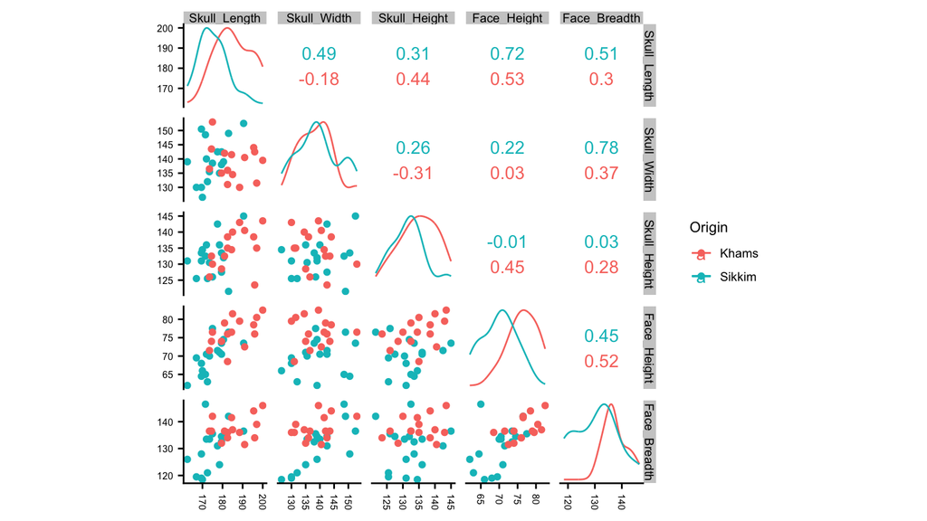

## Tibetan skulls

```r
fm <- lm(cbind(Skull_Length, Skull_Width,
               Skull_Height, Face_Height,
               Face_Breadth) ~ Origin, data = M)
Anova(fm, type = "III")
```

```
##
## Type III MANOVA Tests: Pillai test statistic
##             Df test stat approx F num Df den Df    Pr(>F)
## (Intercept)  1   0.99817  2832.58      5     26 < 2.2e-16 ***
## Origin       1   0.48188     4.84      5     26  0.002936 **
## ---
## Signif. codes:  0 '***' 0.001 '**' 0.01 '*' 0.05 '.' 0.1 ' ' 1
```

## Tibetan skulls

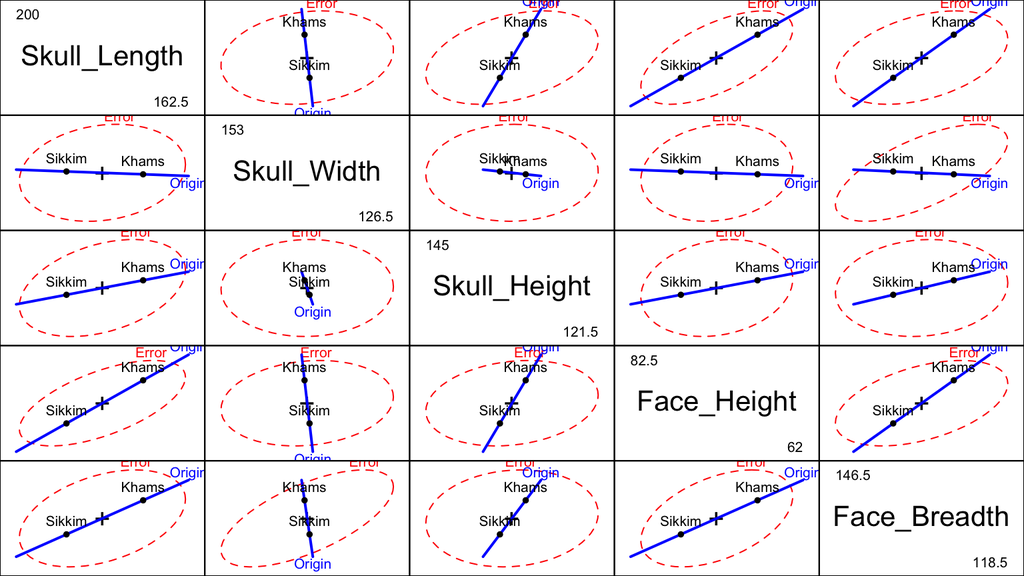

```r
pairs(fm, type = "III")
```

## Quiz 13-2

Lecture 13-3

## References

Borcard, D., F. Gillet, and P. Legendre. 2011. *Numerical Ecology with R*. Springer, New York.

Everitt, B., and T. Hothorn. 2011. *An Introduction to Applied Multivariate Analysis with R*. Springer, New York.

Friendly, M. 2006. Data Ellipses, HE Plots and Reduced-Rank Displays for Multivariate Linear Models: SAS Software and Examples. *Journal of Statistical Software* 17:1–43.

Morant, G. M. 1923. A First Study of the Tibetan Skull. *Biometrika* 14:193–260.

Sinha, R. N., H. A. H. Wallace, and F. S. Chebib. 1969. Canonical Correlation Between Groups of Acarine, Fungal and Environmental Variables in Bulk Grain Ecosystems. *Research in Population Ecology* 11:92–104.

Tabachnick, B. G., and L. S. Fidell. 2013. *Using Multivariate Statistics*. Pearson Education, Boston.